# Analysis of Olymoic Games for sponsor

## Objective of the Proposed Research:

### The purpose of this report is to find good athletes for the sponsors. The report will research four different aspects of data, such as region, Age, Weight, and Height. Before the investigation, I have assumed that the four aspects are related to the number of the medals. The first one is the nation. I will explore which nation has numerous medals in history. The influence of country to an athlete may be better training, policy or the environment. Especially, the war in history may cause some countries to miss the Olympic games. So, I will also compare with the data after 2004. Next, I will show the relationship between age and athletes. Age may be a contributing factor to the change of the athlete's physical status, thus affect his/her ability to win sports games. Additionally, I will also consider the physical data of athletes. I believe that their height and weight play a key role in their performance of games. In conclusion, I will integrate the data from those different aspects and find the character of good players that can help sponsor to choose good athletes.

## 1. Preparation

### //Read the data

```r
athleteEvent <- read.csv("~/Downloads/120-years-of-olympic-history-athletes-and-results/athlete_events.csv")
```

```r
nocRegion <- read.csv("~/Downloads/120-years-of-olympic-history-athletes-and-results/noc_regions.csv")
```

### -Import library we need for the function

```r
library(tidyverse)
```

### -Union two different data "athleteEvent"and "nocRegion" to "oly" file and check it

```r
oly <- athleteEvent %>% inner_join(nocRegion, by = "NOC")
head(oly)
```

| ID | Name | Sex | Age | Height | Weight | Team | NOC | Games | Year | Season | City | Sport | Event | Medal | region | notes |
| --- | --- | --- | --- | --- | --- | --- | --- | --- | --- | --- | --- | --- | --- | --- | --- | --- |
| 1 | A Dijiang | M | 24 | 180 | 80 | China | CHN | 1992 Summer | 1992 | Summer | Barcelona | Basketball | Basketball Men's Basketball | NA | China |  |
| 2 | A Lamusi | M | 23 | 170 | 60 | China | CHN | 2012 Summer | 2012 | Summer | London | Judo | Judo Men's Extra-Lightweight | NA | China |  |
| 3 | Gunnar Nielsen Aaby | M | 24 | NA | NA | Denmark | DEN | 1920 Summer | 1920 | Summer | Antwerpen | Football | Football Men's Football | NA | Denmark |  |
| 4 | Edgar Lindenau Aabye | M | 34 | NA | NA | Denmark/Sweden | DEN | 1900 Summer | 1900 | Summer | Paris | Tug-Of-War | Tug-Of-War Men's Tug-Of-War | Gold | Denmark |  |
| 5 | Christine Jacoba Aaftink | F | 21 | 185 | 82 | Netherlands | NED | 1988 Winter | 1988 | Winter | Calgary | Speed Skating | Speed Skating Women's 500 metres | NA | Netherlands |  |
| 5 | Christine Jacoba Aaftink | F | 21 | 185 | 82 | Netherlands | NED | 1988 Winter | 1988 | Winter | Calgary | Speed Skating | Speed Skating Women's 1,000 metres | NA | Netherlands |  |

### -Check the structure of data. I need to change ID to be factor type becasue one athlete may have participated many different matches.

```r
str(oly)
```

```
'data.frame':	270767 obs. of  17 variables:
 $ ID    : int  1 2 3 4 5 5 5 5 5 5 ...
 $ Name  : Factor w/ 134732 levels "  Gabrielle Marie \"Gabby\" Adcock (White-)",..: 8 9 44318 29412 21469 21469 21469 21469 21469 21469 ...
 $ Sex   : Factor w/ 2 levels "F","M": 2 2 2 2 1 1 1 1 1 1 ...
 $ Age   : int  24 23 24 34 21 21 25 25 27 27 ...
 $ Height: int  180 170 NA NA 185 185 185 185 185 185 ...
 $ Weight: num  80 60 NA NA 82 82 82 82 82 82 ...
 $ Team  : Factor w/ 1184 levels "30. Februar",..: 199 199 273 278 705 705 705 705 705 705 ...
 $ NOC   : chr  "CHN" "CHN" "DEN" "DEN" ...
 $ Games : Factor w/ 51 levels "1896 Summer",..: 38 49 7 2 37 37 39 39 40 40 ...
 $ Year  : int  1992 2012 1920 1900 1988 1988 1992 1992 1994 1994 ...
 $ Season: Factor w/ 2 levels "Summer","Winter": 1 1 1 1 2 2 2 2 2 2 ...
 $ City  : Factor w/ 42 levels "Albertville",..: 6 18 3 27 9 9 1 1 17 17 ...
 $ Sport : Factor w/ 66 levels "Aeronautics",..: 9 33 25 62 54 54 54 54 54 54 ...
 $ Event : Factor w/ 765 levels "Aeronautics Mixed Aeronautics",..: 160 398 349 710 623 619 623 619 623 619 ...
 $ Medal : Factor w/ 3 levels "Bronze","Gold",..: NA NA NA 2 NA NA NA NA NA NA ...
 $ region: Factor w/ 206 levels "Afghanistan",..: 40 40 51 51 130 130 130 130 130 130 ...
 $ notes : Factor w/ 22 levels "","Antigua and Barbuda",..: 1 1 1 1 1 1 1 1 1 1 ...
```

```r
oly$ID <- factor(oly$ID)
```

```r
str(oly)
```

```
'data.frame':	270767 obs. of  17 variables:
 $ ID    : Factor w/ 135404 levels "1","2","3","4",..: 1 2 3 4 5 5 5 5 5 5 ...
 $ Name  : Factor w/ 134732 levels "  Gabrielle Marie \"Gabby\" Adcock (White-)",..: 8 9 44318 29412 21469 21469 21469 21469 21469 21469 ...
 $ Sex   : Factor w/ 2 levels "F","M": 2 2 2 2 1 1 1 1 1 1 ...
 $ Age   : int  24 23 24 34 21 21 25 25 27 27 ...
 $ Height: int  180 170 NA NA 185 185 185 185 185 185 ...
 $ Weight: num  80 60 NA NA 82 82 82 82 82 82 ...
 $ Team  : Factor w/ 1184 levels "30. Februar",..: 199 199 273 278 705 705 705 705 705 705 ...
 $ NOC   : chr  "CHN" "CHN" "DEN" "DEN" ...
 $ Games : Factor w/ 51 levels "1896 Summer",..: 38 49 7 2 37 37 39 39 40 40 ...
 $ Year  : int  1992 2012 1920 1900 1988 1988 1992 1992 1994 1994 ...
 $ Season: Factor w/ 2 levels "Summer","Winter": 1 1 1 1 2 2 2 2 2 2 ...
 $ City  : Factor w/ 42 levels "Albertville",..: 6 18 3 27 9 9 1 1 17 17 ...
 $ Sport : Factor w/ 66 levels "Aeronautics",..: 9 33 25 62 54 54 54 54 54 54 ...
 $ Event : Factor w/ 765 levels "Aeronautics Mixed Aeronautics",..: 160 398 349 710 623 619 623 619 623 619 ...
 $ Medal : Factor w/ 3 levels "Bronze","Gold",..: NA NA NA 2 NA NA NA NA NA NA ...
 $ region: Factor w/ 206 levels "Afghanistan",..: 40 40 51 51 130 130 130 130 130 130 ...
 $ notes : Factor w/ 22 levels "","Antigua and Barbuda",..: 1 1 1 1 1 1 1 1 1 1 ...
```

## 2. Four aspects of data

### - Pipe operator "%>%" is allow the object on the left to passthe first argument to the function on right side.

### - The code is taking out the NA value in Medal column from oly file, then calculate the total sum of each region got.

```r
medalOfNoc <- oly %>% filter(!is.na(Medal)) %>% group_by(region) %>% summarize(NumOfMed = n())
head(medalOfNoc[order(medalOfNoc$NumOfMed, decreasing = T), ])
```

| region | NumOfMed |
| --- | --- |
| USA | 5637 |
| Russia | 3947 |
| Germany | 3756 |
| UK | 2068 |
| France | 1777 |
| Italy | 1637 |

### -Filtered out the data before 2004 because some countries cannot participate past Olmypics due to war or some issues.

```r
medalOfNoc2004 <- oly %>% filter(Year >= 2004, !is.na(Medal))  %>% group_by(region) %>% summarize(NumOfMed2004 = n())
head(medalOfNoc2004[order(medalOfNoc2004$NumOfMed2004, decreasing = T), ])
```

| region | NumOfMed2004 |
| --- | --- |
| USA | 1305 |
| Russia | 720 |
| Germany | 645 |
| China | 563 |
| Australia | 510 |
| Canada | 421 |

### -Look at the data above, we can see that two different period of time have the same top three countries. So, we can consider that the athletes from USA, Russia, and Germany have hight percentage to win medals.

## B. Relationship between number of medal and age.

### - Distribution of medal based on age, and filter out age groups which didn't have medal. And, show 10 largest number of players with medals connect with age.

```r
medalAge <- oly %>% filter(!is.na(Medal)) %>% group_by(Age) %>% summarize(AgeNumMed=n())
head(medalAge[order(medalAge$AgeNumMed, decreasing = T), ], n = 10)
```

| Age | AgeNumMed |
| --- | --- |
| 23 | 3395 |
| 24 | 3289 |
| 22 | 3159 |
| 25 | 3122 |
| 26 | 2923 |
| 27 | 2689 |
| 21 | 2682 |
| 28 | 2334 |
| 20 | 2004 |
| 29 | 1941 |

### -Consideration of the population on each age group and 10 largest number of players with medals in age group.

```r
NumAge <- oly %>% group_by(Age) %>% summarize(numAge = n())
head(NumAge[order(NumAge$numAge, decreasing = T), ], n = 10)
```

| Age | numAge |
| --- | --- |
| 23 | 21848 |
| 24 | 21708 |
| 22 | 20793 |
| 25 | 19676 |
| 21 | 19126 |
| 26 | 17663 |
| 27 | 16014 |
| 20 | 15246 |
| 28 | 14029 |
| 19 | 11630 |

### -Analyize the data above, we found the top 10 of rank of ages in both data are alomst same. It means that the players in 23 years old have more high rate to win the game due to the number of Participant. Thus, we can speculate the relationship between age and medal is unrelated. we will have plot about it later.

## C. Relationship between number of medal and height.

### - Show 10 largest number of medals in Height group.

### - I take out the data which is has NA value in medal and height columns.

```r
heightMedal <- oly %>% filter(!is.na(Medal), !is.na(Height)) %>% group_by(Height) %>% summarize(NumHeightMedal = n())
head(heightMedal[order(heightMedal$NumHeightMedal, decreasing = T), ], n = 10)
```

| Height | NumHeightMedal |
| --- | --- |
| 180 | 1795 |
| 178 | 1591 |
| 170 | 1568 |
| 183 | 1468 |
| 175 | 1408 |
| 185 | 1217 |
| 173 | 1155 |
| 172 | 1041 |
| 168 | 976 |
| 182 | 960 |

### -From the data above, in Genera, the better height for a athlete to win is 180(cm).

### D. Relationship between number of medal and weight.

### -Show 10 largest number of medals in weight group.

### - I filtered out the data which is has NA value in medal and weight columns.

```r
weightMedal <- oly %>% filter(!is.na(Medal), !is.na(Weight)) %>% group_by(Weight) %>% summarize(NumWeightMedal = n())
head(weightMedal[order(weightMedal$NumWeightMedal, decreasing = T), ], n = 10)
```

| Weight | NumWeightMedal |
| --- | --- |
| 70 | 1260 |
| 75 | 1187 |
| 68 | 945 |
| 80 | 935 |
| 73 | 918 |
| 60 | 915 |
| 72 | 894 |
| 65 | 845 |
| 78 | 780 |
| 64 | 765 |

### - In here, we can see the top 10 of weight for winner. The first one is 70(kg).

## 3. Five columns I chose

```r
head(oly [, c("Height","Weight","Age","region","Medal")], n= 0)
```

| Height | Weight | Age | region | Medal |
| --- | --- | --- | --- | --- |

## 4. Data of five columns

```r
colChoose1 <- filter(oly, !is.na(Medal), Height == "180", Weight == "75", region == "USA" )
head(select (colChoose1, Height, Weight, Age, region, Medal), n = 10)
summary(colChoose1)
```

| Height | Weight | Age | region | Medal |
| --- | --- | --- | --- | --- |
| 180 | 75 | 22 | USA | Gold |
| 180 | 75 | 23 | USA | Gold |
| 180 | 75 | 34 | USA | Bronze |
| 180 | 75 | 42 | USA | Gold |
| 180 | 75 | 24 | USA | Gold |
| 180 | 75 | 19 | USA | Bronze |
| 180 | 75 | 19 | USA | Bronze |
| 180 | 75 | 25 | USA | Bronze |
| 180 | 75 | 20 | USA | Silver |
| 180 | 75 | 20 | USA | Gold |

```
       ID                               Name    Sex         Age
 94865  : 3   Erik K. Vendt               : 3   F: 3   Min.   :18.00
 125841 : 3   Paul Henry Pilgrim          : 3   M:26   1st Qu.:20.00
 10256  : 2   John Edward Ferris          : 2          Median :22.00
 35055  : 2   Leonard Harvey Nitz         : 2          Mean   :24.41
 45391  : 2   Millard Frank Hampton, Jr.  : 2          3rd Qu.:26.00
 86564  : 2   William Bruce "Bill" Bentsen: 2          Max.   :45.00
 (Other):15   (Other)                     :15
     Height        Weight                       Team        NOC
 Min.   :180   Min.   :75   United States         :27   Length:29
 1st Qu.:180   1st Qu.:75   New York Athletic Club: 1   Class :character
 Median :180   Median :75   Widgeon               : 1   Mode  :character
 Mean   :180   Mean   :75   30. Februar           : 0
 3rd Qu.:180   3rd Qu.:75   A North American Team : 0
 Max.   :180   Max.   :75   Acipactli             : 0
                            (Other)               : 0
         Games         Year         Season            City              Sport
 1964 Summer: 4   Min.   :1904   Summer:27   Athina     : 4   Swimming     :9
 1906 Summer: 2   1st Qu.:1964   Winter: 2   Tokyo      : 4   Athletics    :8
 1968 Summer: 2   Median :1976               Los Angeles: 3   Cycling      :2
 1972 Summer: 2   Mean   :1973               Atlanta    : 2   Equestrianism:2
 1976 Summer: 2   3rd Qu.:1996               Barcelona  : 2   Sailing      :2
 1984 Summer: 2   Max.   :2016               Mexico City: 2   Basketball   :1
 (Other)    :15                              (Other)    :12   (Other)      :5
                                           Event       Medal
 Athletics Men's 4 x 100 metres Relay         : 3   Bronze: 9
 Athletics Men's 200 metres                   : 2   Gold  :14
 Swimming Men's 4 x 200 metres Freestyle Relay: 2   Silver: 6
 Swimming Men's 400 metres Individual Medley  : 2
 Athletics Men's 4 mile, Team                 : 1
 Athletics Men's 400 metres                   : 1
 (Other)                                      :18
            region                   notes
 USA           :29                      :29
 Afghanistan   : 0   Antigua and Barbuda: 0
 Albania       : 0   Australasia        : 0
 Algeria       : 0   Bohemia            : 0
 American Samoa: 0   Crete              : 0
 Andorra       : 0   Hong Kong          : 0
 (Other)       : 0   (Other)            : 0
```

### -In order to compare with the data above I used the function to find the data which is Height == "180", Weight == "75", region == "Russia".

```r
colChoose2 <- filter(oly, !is.na(Medal), Height == "180", Weight == "75", region == "Russia" )
head(select (colChoose2, Height, Weight, Age, region, Medal),n = 10)
summary (colChoose2)
```

| Height | Weight | Age | region | Medal |
| --- | --- | --- | --- | --- |
| 180 | 75 | 18 | Russia | Gold |
| 180 | 75 | 26 | Russia | Silver |
| 180 | 75 | 25 | Russia | Gold |
| 180 | 75 | 29 | Russia | Silver |
| 180 | 75 | 27 | Russia | Gold |
| 180 | 75 | 25 | Russia | Silver |
| 180 | 75 | 21 | Russia | Silver |
| 180 | 75 | 25 | Russia | Gold |
| 180 | 75 | 23 | Russia | Bronze |
| 180 | 75 | 23 | Russia | Silver |

```
       ID                                        Name   Sex         Age
 96994  :4   Gennady Sergeyevich Prigoda           :4   F: 4   Min.   :18.00
 123916 :3   Maigonis Valdmanis                    :3   M:13   1st Qu.:23.00
 64840  :2   Vitaly Aleksandrovich Petrakov        :2          Median :25.00
 94014  :2   Yevgeny Nikolayevich Kulikov          :2          Mean   :24.06
 13608  :1   Lyubov Andreyevna Talalayeva          :1          3rd Qu.:26.00
 34422  :1   Lyudmila Vasilyevna Borozna (-Zhigily):1          Max.   :29.00
 (Other):4   (Other)                               :4
     Height        Weight                      Team        NOC
 Min.   :180   Min.   :75   Soviet Union         :14   Length:17
 1st Qu.:180   1st Qu.:75   Russia               : 2   Class :character
 Median :180   Median :75   Unified Team         : 1   Mode  :character
 Mean   :180   Mean   :75   30. Februar          : 0
 3rd Qu.:180   3rd Qu.:75   A North American Team: 0
 Max.   :180   Max.   :75   Acipactli            : 0
                            (Other)              : 0
         Games        Year         Season            City             Sport
 1988 Summer:4   Min.   :1952   Summer:13   Seoul      :4   Speed Skating:4
 1976 Summer:2   1st Qu.:1972   Winter: 4   Innsbruck  :2   Swimming     :4
 1952 Summer:1   Median :1980               Montreal   :2   Basketball   :3
 1956 Summer:1   Mean   :1979               Barcelona  :1   Cycling      :2
 1960 Summer:1   3rd Qu.:1988               Helsinki   :1   Football     :1
 1964 Winter:1   Max.   :2016               Lake Placid:1   Rowing       :1
 (Other)    :7                              (Other)    :6   (Other)      :2
                                           Event      Medal
 Basketball Men's Basketball                  :3   Bronze: 3
 Speed Skating Men's 500 metres               :3   Gold  : 4
 Cycling Men's Team Pursuit, 4,000 metres     :2   Silver:10
 Swimming Men's 4 x 100 metres Freestyle Relay:2
 Football Men's Football                      :1
 Rowing Women's Coxed Eights                  :1
 (Other)                                      :5
            region                   notes
 Russia        :17                      :17
 Afghanistan   : 0   Antigua and Barbuda: 0
 Albania       : 0   Australasia        : 0
 Algeria       : 0   Bohemia            : 0
 American Samoa: 0   Crete              : 0
 Andorra       : 0   Hong Kong          : 0
 (Other)       : 0   (Other)            : 0
```

## 6.Plot of population and the number of medal in each age group

### - Use the function "qplot" to draw the plots. I use "Age" to be X and "numAge(number of age)" to be Y, and data from oly file.

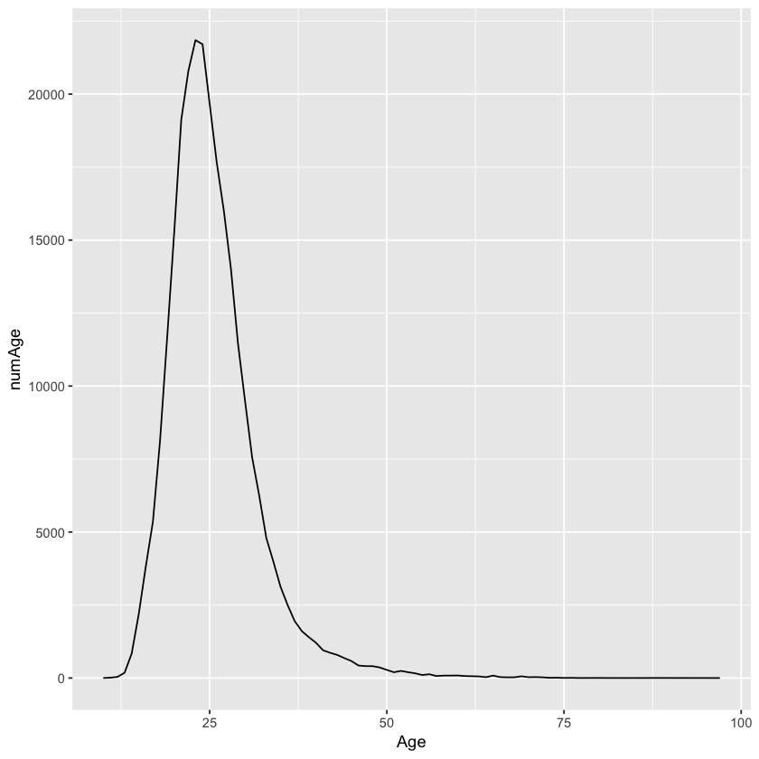

```r
qplot(Age, numAge, data = NumAge,
geom = c("line"))
```

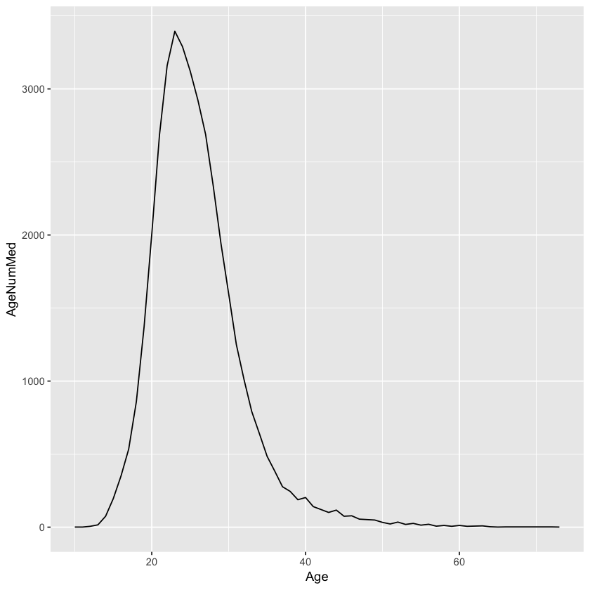

```r
qplot(Age, AgeNumMed, data = medalAge,
     geom = c("line"))
```

## 9.Extra data analytics

### -a.Age

```r
head(sort(NumAge$Age, decreasing = F), 15)
```

1. 10

2. 11

3. 12

4. 13

5. 14

6. 15

7. 16

8. 17

9. 18

10. 19

11. 20

12. 21

13. 22

14. 23

15. 24

```r
head(sort(NumAge$Age, decreasing = T), 15)
```

1. 97

2. 96

3. 88

4. 84

5. 81

6. 80

7. 77

8. 76

9. 75

10. 74

11. 73

12. 72

13. 71

14. 70

15. 69

### -After I used the function to sort out the data of age, the interesting is that the youngest participant in Olympic is only 10 years old. I am suprise about it. and also the oldest player is 97 already. That two are over my imagination.

### b.Height

```r
head(sort(heightMedal$Height, decreasing = T), 15)
```

1. 223

2. 220

3. 219

4. 218

5. 217

6. 216

7. 215

8. 214

9. 213

10. 212

11. 211

12. 210

13. 209

14. 208

15. 207

```r
head(sort(heightMedal$Height, decreasing = F), 15)
```

1. 136

2. 137

3. 138

4. 139

5. 140

6. 141

7. 142

8. 143

9. 144

10. 145

11. 146

12. 147

13. 148

14. 149

15. 150

### -The hightest player who has medal in Olympic Games was 223 and the lowest player is 136.